# Grad School Survey

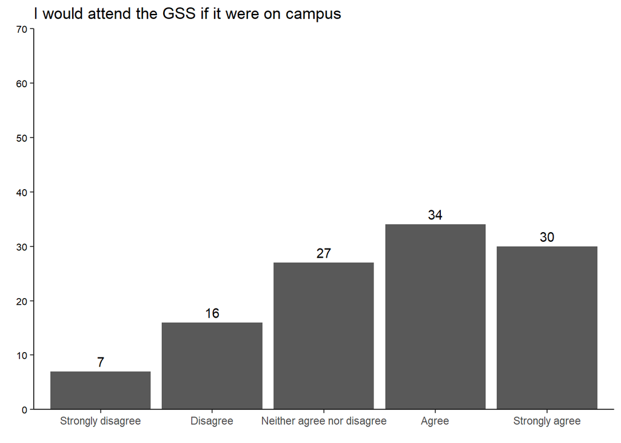

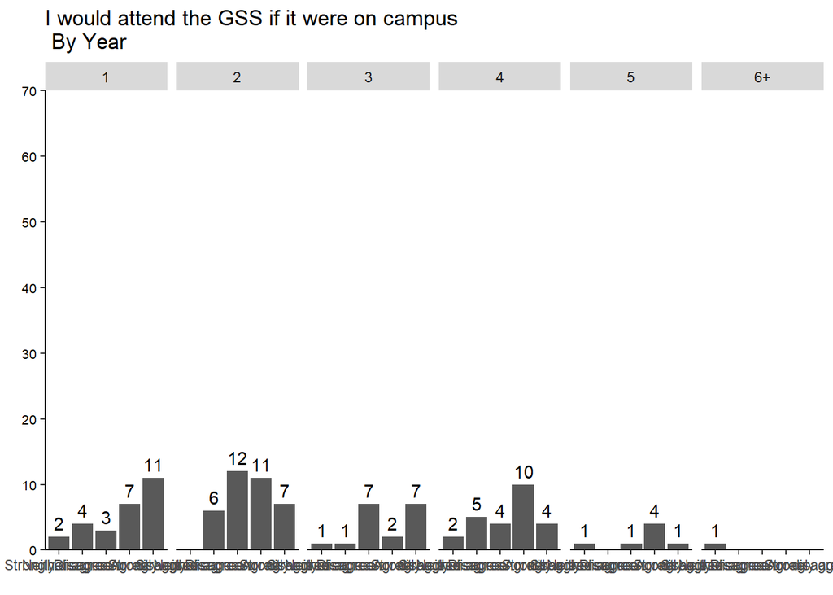

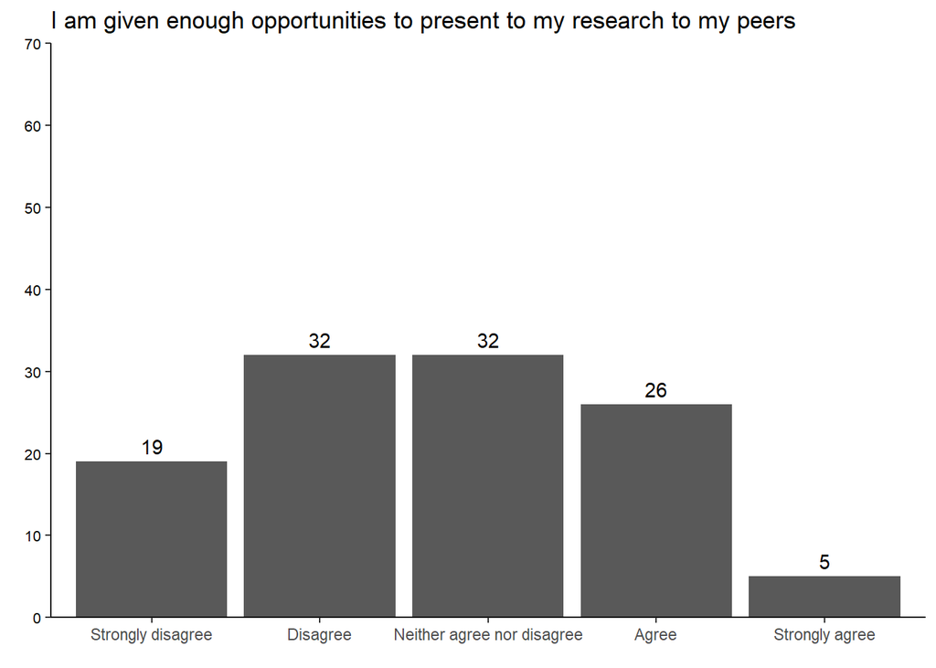

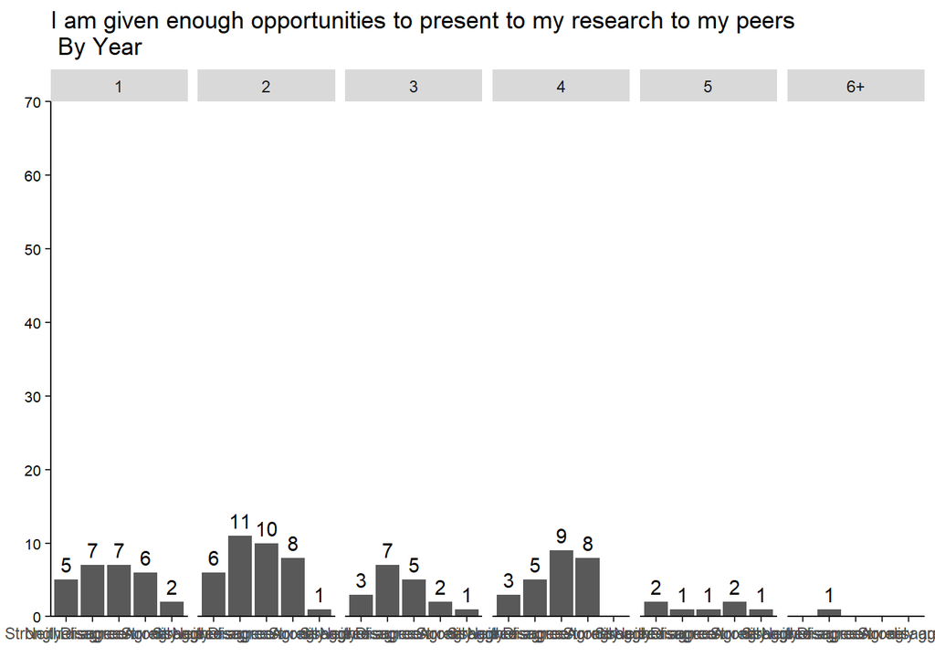

[2 more figures not shown]

## In your opinion, What is the most valuable part of the Graduate Student Symposium (GSS)?

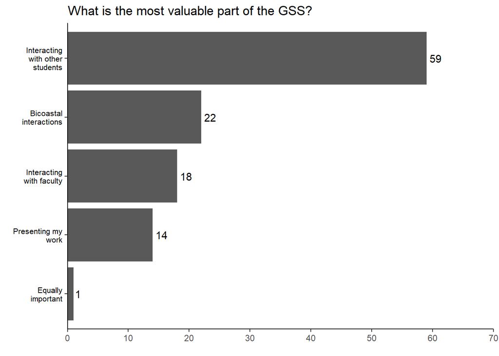

## Satisfaction with…

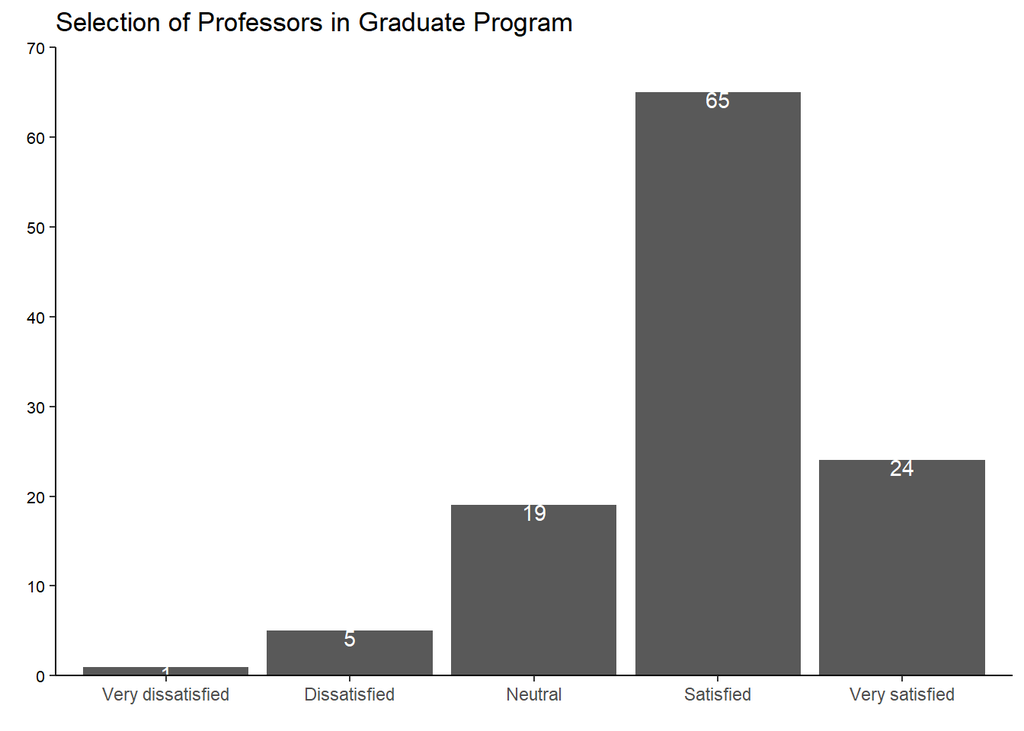

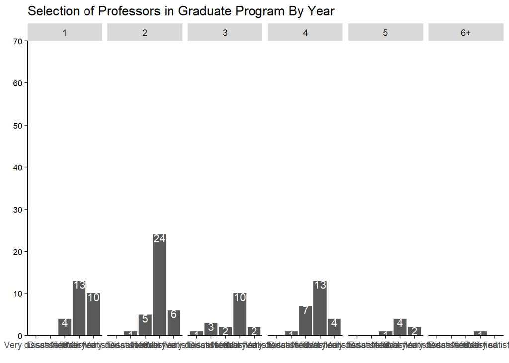

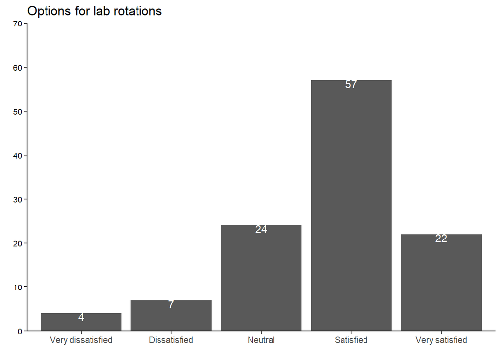

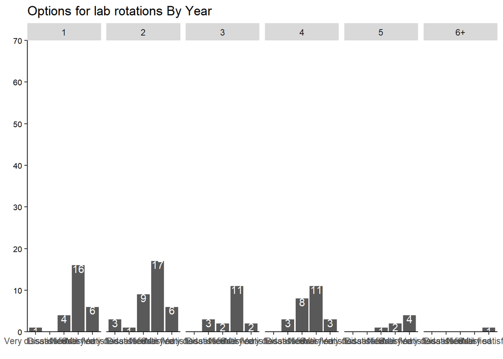

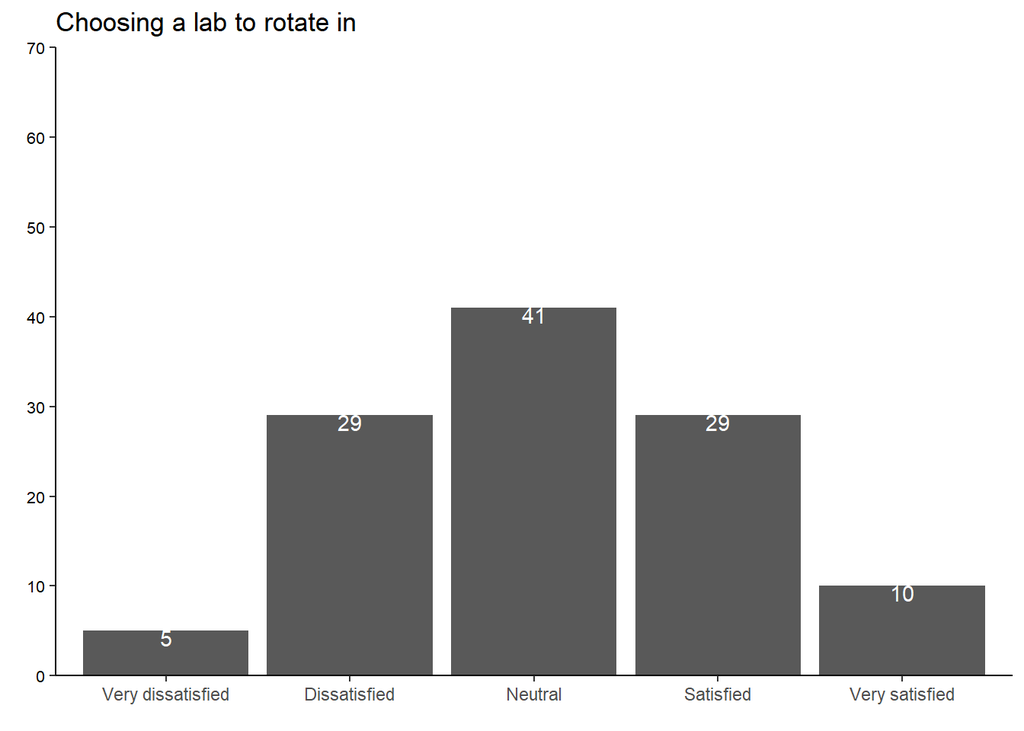

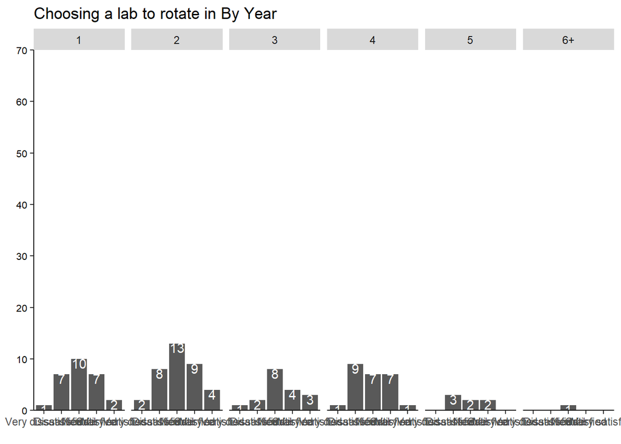

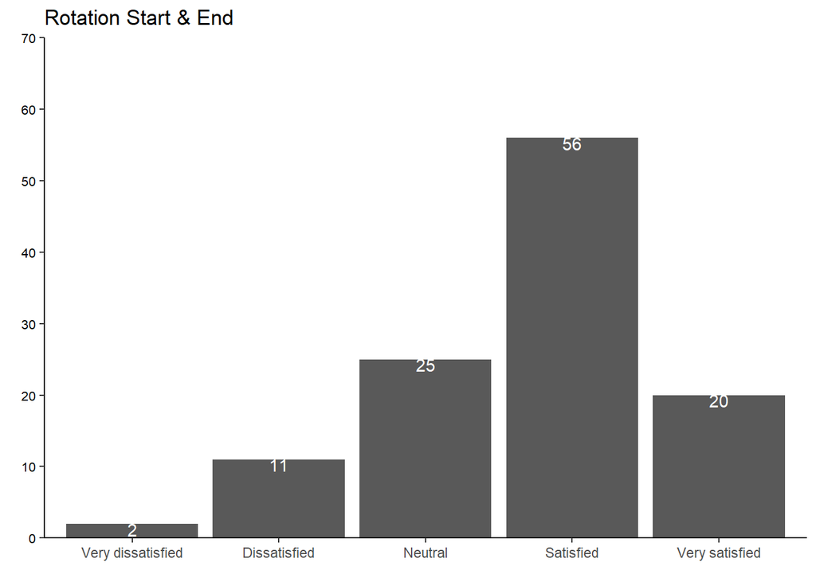

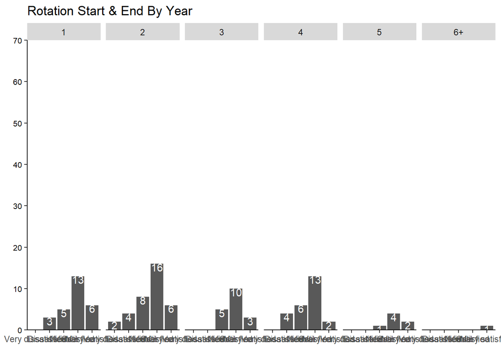

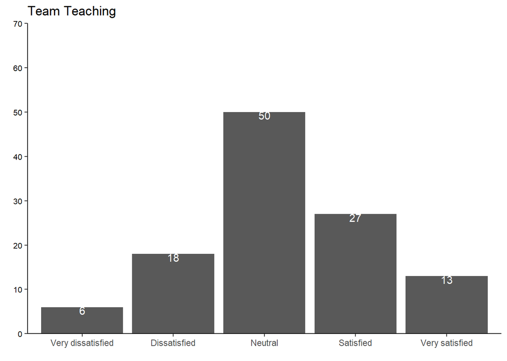

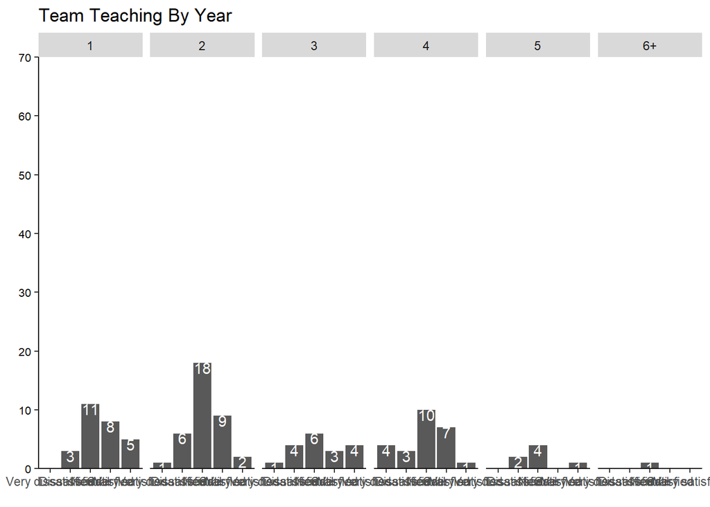

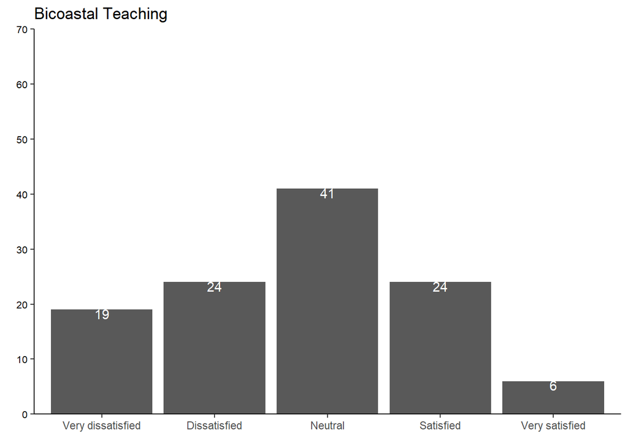

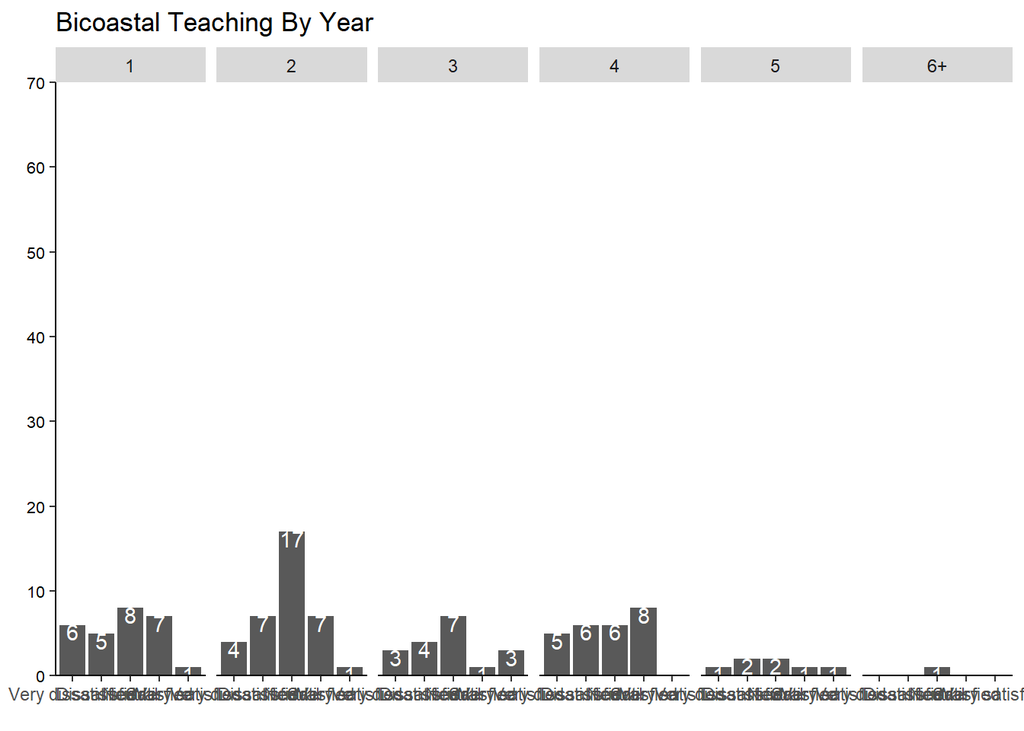

[8 more figures not shown]

## Why did your education not meet your expectations? (Word Cloud)

Text cleaning

Transformation of data to a matrix then to dataframe. Create a vector (docs2) and complete the stemmed words.

Build Word Cloud with stemmed words as input word, and frequency.

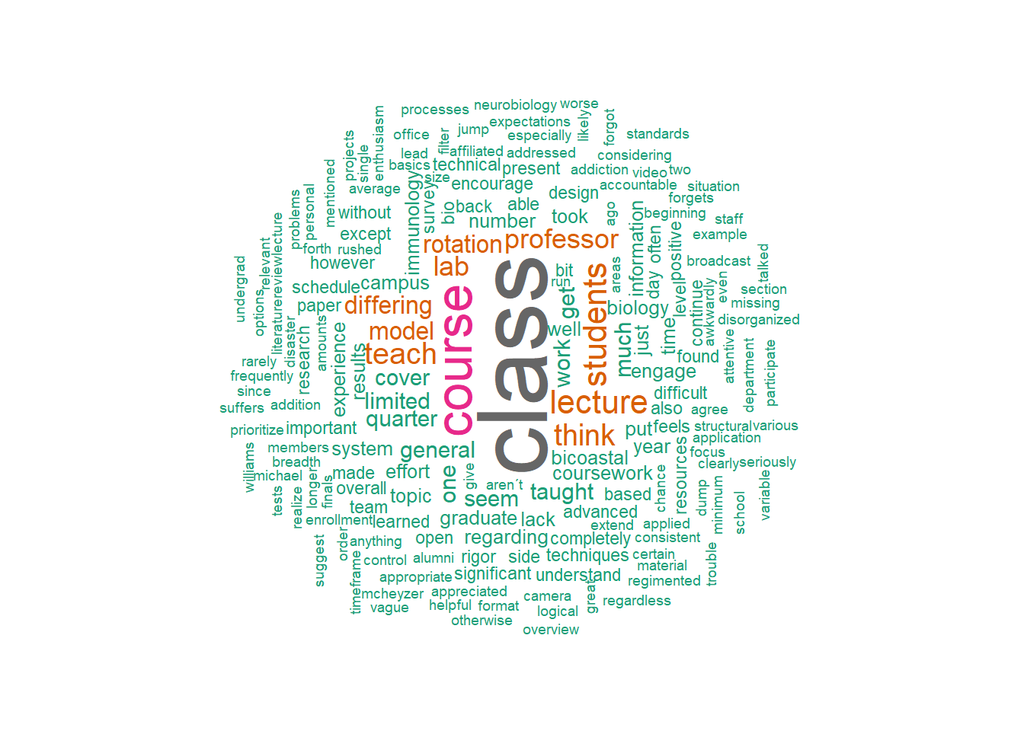

## Recommend improvements to 1st and 2nd Year satisfaction? (Word Cloud)

Text cleaning

Transformation of data to a matrix then to dataframe. Create a vector (docs2) and complete the stemmed words.

Build Word Cloud with stemmed words as input word, and frequency.

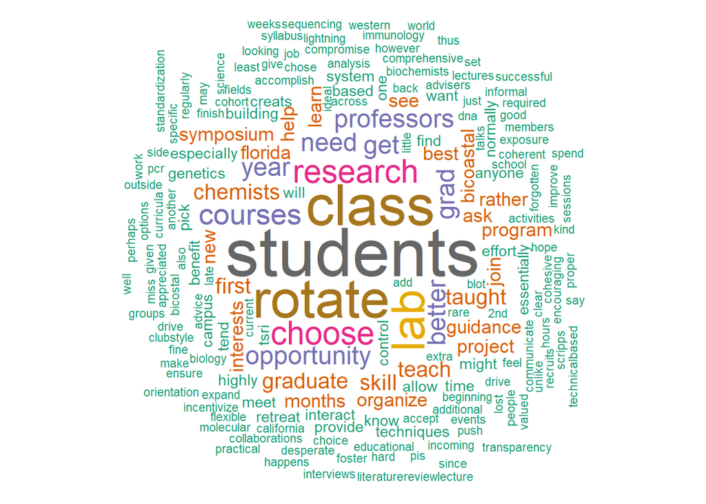

## Satisfaction on other aspects of Scripps.

How satisfied are you with…

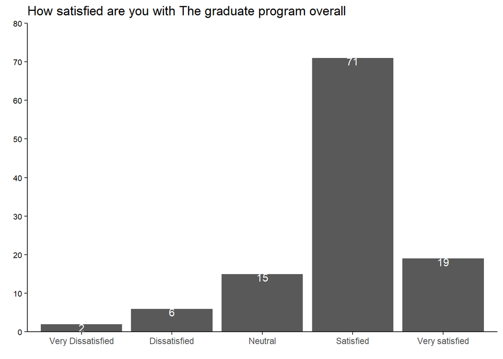

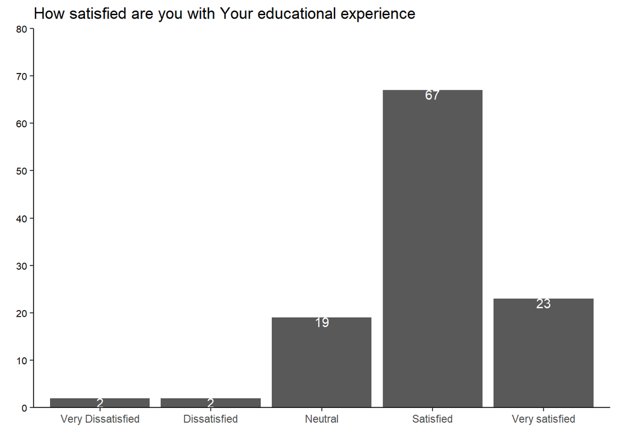

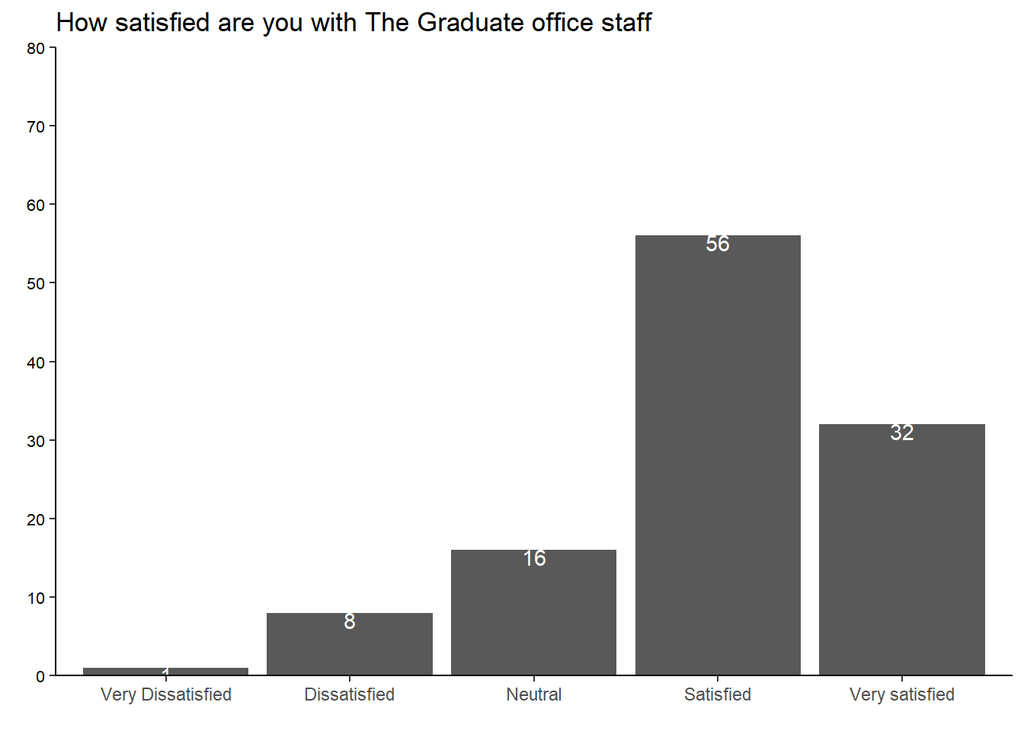

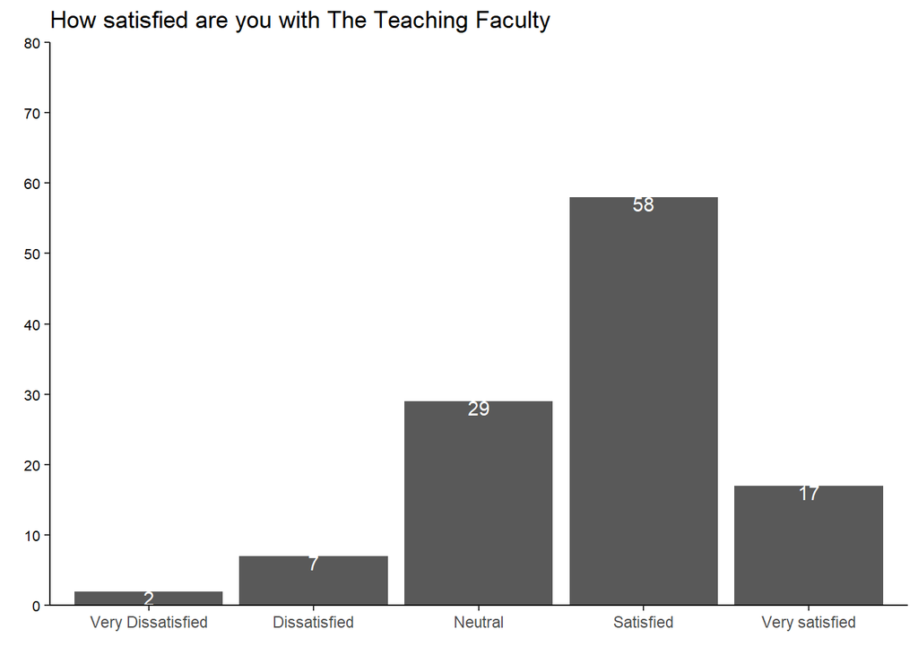

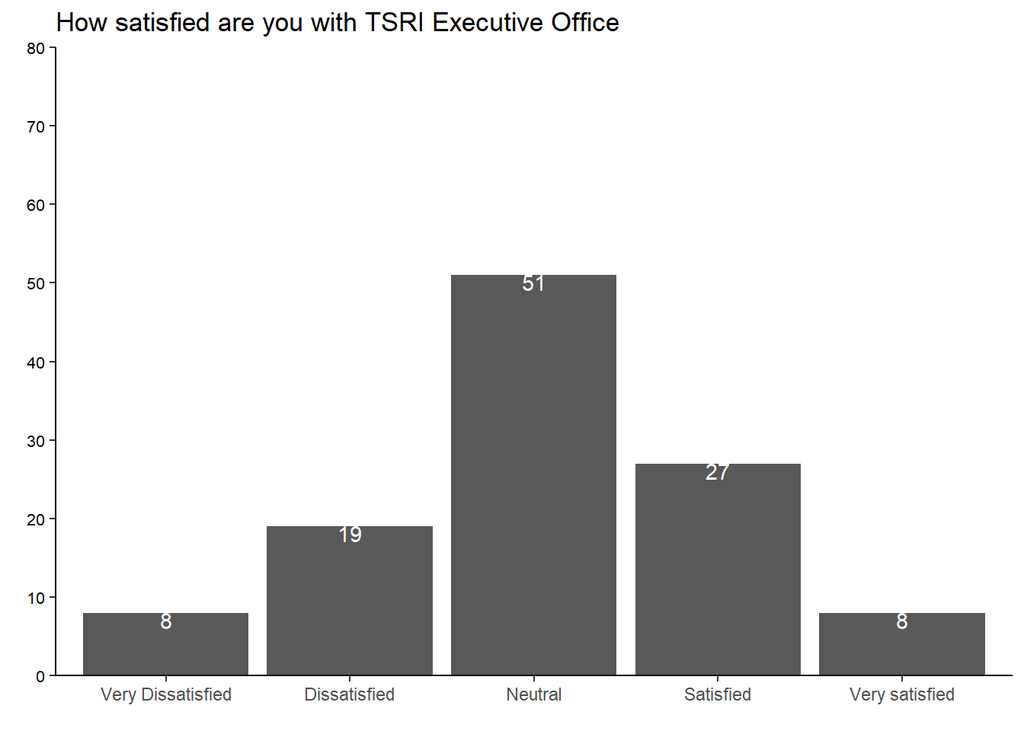

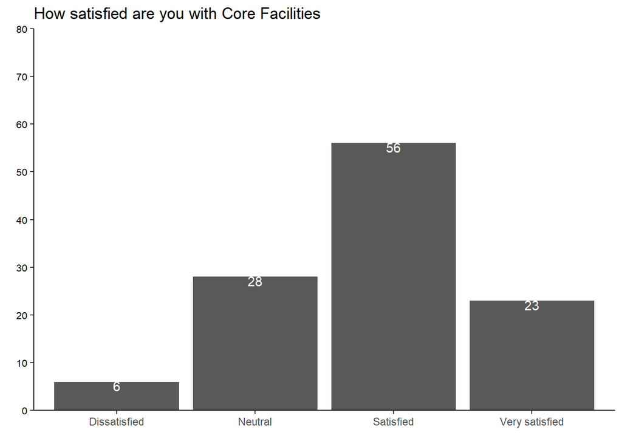

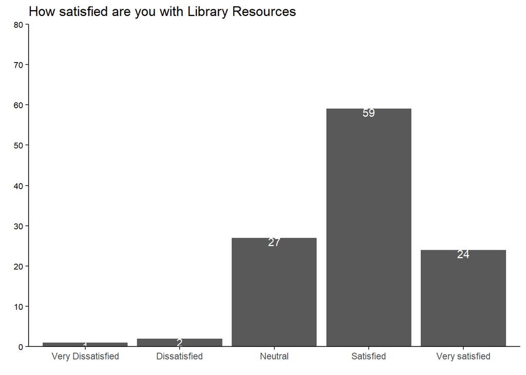

## Recommendations for co-mentorship (Word Cloud)

Text cleaning

Transformation of data to a matrix then to dataframe. Create a vector (docs2) and complete the stemmed words.

Build Word Cloud with stemmed words as input word, and frequency.

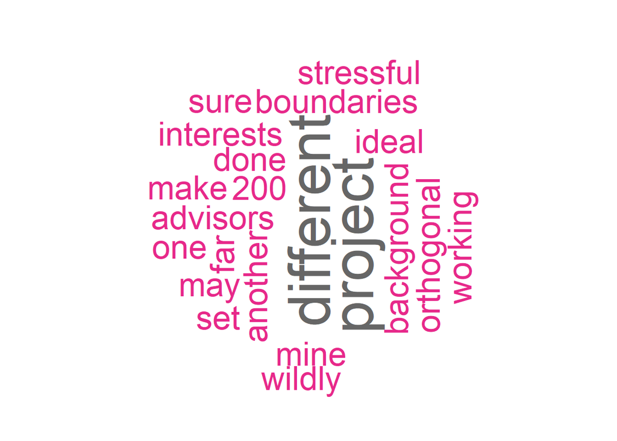